# Project_Practical Machine Learning

Yato

April 3, 2017

# Introduction

The goal of the project is to predict the manner in which they did the exercise. I will use data from accelerometers on the belt, forearm, arm, and dumbell of 6 participants. They were asked to perform barbell lifts correctly and incorrectly in 5 different ways. This is the “classe” variable in the training set. I will use any of the other variables to predict with the “classe” variable. The following shows how the model built by using cross validation.

# Load the packages

```r
library(caret)
library(randomForest)
library(rpart)
library(rattle)
```

# Load the data

```r
training <- read.csv("https://d396qusza40orc.cloudfront.net/predmachlearn/pml-training.csv")
testing <- read.csv("https://d396qusza40orc.cloudfront.net/predmachlearn/pml-testing.csv")
dim(training)
```

```
## [1] 19622   160
```

```r
dim(testing)
```

```
## [1]  20 160
```

# Data Partition

```r
set.seed(17717)
inTrain <- createDataPartition(y = training$classe, p = 0.6, list = FALSE)
train1 <- training[inTrain, ]
train2 <- training[-inTrain, ]
dim(train1)
```

```
## [1] 11776   160
```

```r
dim(train2)
```

```
## [1] 7846  160
```

# Remove the near zero variables

```r
nzv <- nearZeroVar(train1)
train1 <- train1[, -nzv]
train2 <- train2[, -nzv]
dim(train1)
```

```
## [1] 11776   105
```

```r
dim(train2)
```

```
## [1] 7846  105
```

# Remove the missing values

```r
train1 <- train1[, colSums(is.na(train1)) == 0]
train2 <- train2[, colSums(is.na(train2)) == 0]
sum(is.na(train1))
```

```
## [1] 0
```

```r
sum(is.na(train2))
```

```
## [1] 0
```

# Remove the useless variables

```r
train1 <- subset(train1, select = -c(1:7))
train2 <- subset(train2, select = -c(1:7))
dim(train1)
```

```
## [1] 11776    52
```

```r
dim(train2)
```

```
## [1] 7846   52
```

# Model training

Firstly set the seed so the study can be reproducible. Secondly, I consider using cross validation to predict the outcome. In general, k=5 or k= 10 is most commonly used value when doing k-fold cross validation, Here i set k=5 to save a little running time. Then I use the rpart, gbm and the random-forest technique to generate a predictive model, respectively.

```r
set.seed(33833)
myControl <- trainControl(method = "cv", number = 5)
mod2 <- train(classe ~ ., method = "rpart", trControl=myControl, data = train1)
mod3 <- train(classe ~ ., method = "gbm", verbose = FALSE, trControl=myControl, data = train1)
mod1 <- train(classe ~ ., method = "rf", trControl=myControl, data = train1)

pred1 <- predict(mod1, train2)
pred2 <- predict(mod2, train2)
pred3 <- predict(mod3, train2)

cm1 <- confusionMatrix(train2$classe, pred1)
cm2 <- confusionMatrix(train2$classe, pred2)
cm3 <- confusionMatrix(train2$classe, pred3)
```

## The accuracy and Out-of-sample Error is obtained by the following

```r
Accuracy <- cbind( cm1$overall[1], cm2$overall[1], cm3$overall[1]); Accuracy
```

```
##               [,1]      [,2]      [,3]
## Accuracy 0.9942646 0.4871272 0.9644405
```

```r
error <- 1 - Accuracy; row.names(error) <- "Out-of-Sample Error"; error
```

```
##                            [,1]      [,2]       [,3]
## Out-of-Sample Error 0.005735407 0.5128728 0.03555952
```

The accuracy of the three prediction models are 0.9943, 0.4871 and 0.9644. The out of sample errors are 0.0057, 0.5129 and 0.03556, respectively. From the accuracy of the three prediction models, the first model with random forest approach has the highest accuracy (0.9943) and the lowest out-of-sample error(0.0057). So i will use the first model to get the predicted result on testing data.

```r
mod1
```

```
## Random Forest
##
## 11776 samples
##    51 predictor
##     5 classes: 'A', 'B', 'C', 'D', 'E'
##
## No pre-processing
## Resampling: Cross-Validated (5 fold)
## Summary of sample sizes: 9420, 9420, 9422, 9421, 9421
## Resampling results across tuning parameters:
##
##   mtry  Accuracy   Kappa
##    2    0.9866679  0.9831310
##   26    0.9889610  0.9860340
##   51    0.9845452  0.9804475
##
## Accuracy was used to select the optimal model using  the largest value.
## The final value used for the model was mtry = 26.
```

```r
cm1
```

```
## Confusion Matrix and Statistics
##
##           Reference
## Prediction    A    B    C    D    E
##          A 2232    0    0    0    0
##          B    9 1507    2    0    0
##          C    0    7 1357    4    0
##          D    0    1   12 1272    1
##          E    0    0    2    7 1433
##
## Overall Statistics
##
##                Accuracy : 0.9943
##                  95% CI : (0.9923, 0.9958)
##     No Information Rate : 0.2856
##     P-Value [Acc > NIR] : < 2.2e-16
##
##                   Kappa : 0.9927
##  Mcnemar's Test P-Value : NA
##
## Statistics by Class:
##
##                      Class: A Class: B Class: C Class: D Class: E
## Sensitivity            0.9960   0.9947   0.9883   0.9914   0.9993
## Specificity            1.0000   0.9983   0.9983   0.9979   0.9986
## Pos Pred Value         1.0000   0.9928   0.9920   0.9891   0.9938
## Neg Pred Value         0.9984   0.9987   0.9975   0.9983   0.9998
## Prevalence             0.2856   0.1931   0.1750   0.1635   0.1828
## Detection Rate         0.2845   0.1921   0.1730   0.1621   0.1826
## Detection Prevalence   0.2845   0.1935   0.1744   0.1639   0.1838
## Balanced Accuracy      0.9980   0.9965   0.9933   0.9946   0.9989
```

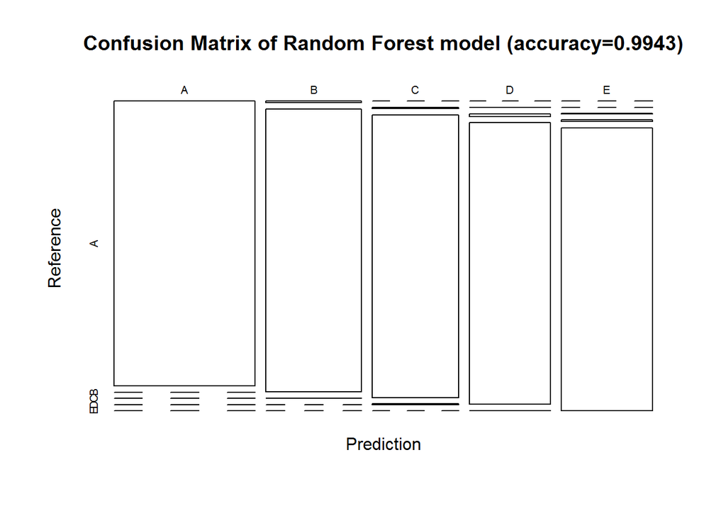

```r
plot(cm1$table, col = cm1$byClass, main = "Confusion Matrix of Random Forest model (accuracy=0.9943)")
```

# Get the final predicted result

```r
finalpred <- predict(mod1, testing)
finalpred
```

```
##  [1] B A B A A E D B A A B C B A E E A B B B
## Levels: A B C D E
```